# Medical Appointments Data Analysis

- Introduction
- Data Wrangling
- Exploratory Data Analysis
- Conclusions

## Introduction

> The conclusion of these findings can assist in predicting whether a patient will show up for their scheduled appointment.

**Step 1**: Imported all the neccessary libraries to conduct the analysis.

- I imported pandas because it offers data structures and operations that I can use to manipulate and analyze the data
- I then imported matplotlib because it provides object-oriented API for embedding plots and garphs
- I imported numpy because it provides support for mathematical functions
- I imported seaborn because it provides a high-level interface for drawing attractive and informative statistical graphics.

```python
import pandas as pd
import numpy as np
import matplotlib.pyplot as plt
%matplotlib inline
import seaborn as sns
```

## Data Wrangling

> In this section of the report, I will load in the data to check for typos, missing or errant data, and then trim and clean the dataset for analysis.

**Step 2**: I load and read the data using pandas and print a few lines to inspect the data.

Once inspected and the columns and data-types in the columns have been viewed, I can see which parts need cleaning and which columns can be used for further analysis

```python
df = pd.read_csv('MedicalApp.csv')
df.head()
```

|  | PatientId | AppointmentID | Gender | ScheduledDay | AppointmentDay | Age | Neighbourhood | Scholarship | Hipertension | Diabetes | Alcoholism | Handcap | SMS_received | No-show |
| --- | --- | --- | --- | --- | --- | --- | --- | --- | --- | --- | --- | --- | --- | --- |
| 0 | 2.987250e+13 | 5642903 | F | 2016-04-29T18:38:08Z | 2016-04-29T00:00:00Z | 62 | JARDIM DA PENHA | 0 | 1 | 0 | 0 | 0 | 0 | No |
| 1 | 5.589980e+14 | 5642503 | M | 2016-04-29T16:08:27Z | 2016-04-29T00:00:00Z | 56 | JARDIM DA PENHA | 0 | 0 | 0 | 0 | 0 | 0 | No |
| 2 | 4.262960e+12 | 5642549 | F | 2016-04-29T16:19:04Z | 2016-04-29T00:00:00Z | 62 | MATA DA PRAIA | 0 | 0 | 0 | 0 | 0 | 0 | No |
| 3 | 8.679510e+11 | 5642828 | F | 2016-04-29T17:29:31Z | 2016-04-29T00:00:00Z | 8 | PONTAL DE CAMBURI | 0 | 0 | 0 | 0 | 0 | 0 | No |
| 4 | 8.841190e+12 | 5642494 | F | 2016-04-29T16:07:23Z | 2016-04-29T00:00:00Z | 56 | JARDIM DA PENHA | 0 | 1 | 1 | 0 | 0 | 0 | No |

**Step 3**: I checked the shape of the dataset to inpect how many rows(checking the amount of appointments in this dataset) and columns(checking how many catagories are in this dataset)

As part of the data wrangling process, I check the shape to see how many scheduled appointments are part of the dataset

```python
df.shape
```

```
(110527, 14)
```

**Step 4**: I inspect to see the dataset's data-type's incase there are any that might need to be converted to make the analysis process easier and I check for any missing or null values so they can be cleaned.

> This dataset is complete and has no null or missing values and the data types will be kept the same

```python
df.info()
```

```
<class 'pandas.core.frame.DataFrame'>
RangeIndex: 110527 entries, 0 to 110526
Data columns (total 14 columns):
 #   Column          Non-Null Count   Dtype
---  ------          --------------   -----
 0   PatientId       110527 non-null  float64
 1   AppointmentID   110527 non-null  int64
 2   Gender          110527 non-null  object
 3   ScheduledDay    110527 non-null  object
 4   AppointmentDay  110527 non-null  object
 5   Age             110527 non-null  int64
 6   Neighbourhood   110527 non-null  object
 7   Scholarship     110527 non-null  int64
 8   Hipertension    110527 non-null  int64
 9   Diabetes        110527 non-null  int64
 10  Alcoholism      110527 non-null  int64
 11  Handcap         110527 non-null  int64
 12  SMS_received    110527 non-null  int64
 13  No-show         110527 non-null  object
dtypes: float64(1), int64(8), object(5)
memory usage: 11.8+ MB
```

**Step 5**: Checking for general duplicates in the appointmentID to make sure that similar data hasn't been repeated.

I used AppointmentID because it has to have unique values for every appointment made, the PatientID values can be repeated because the same patient can go seek medical help for different reasons, more than once.

```python
df.AppointmentID.duplicated().sum()
```

```
0
```

**Step 6**: Checking for possible unique values on the columns to see if any strange values show up that should be cleaned in the data cleaning step

```python
print(df.Gender.unique())
print(sorted(df.Age.unique()))
print(sorted(df.Neighbourhood.unique()))
print(df.Scholarship.unique())
print(df.Hipertension.unique())
print(df.Diabetes.unique())
print(df.Alcoholism.unique())
print(df.Handcap.unique())
print(df.SMS_received.unique())
print(df['No-show'].unique())
```

```
['F' 'M']
[-1, 0, 1, 2, 3, 4, 5, 6, 7, 8, 9, 10, 11, 12, 13, 14, 15, 16, 17, 18, 19, 20, 21, 22, 23, 24, 25, 26, 27, 28, 29, 30, 31, 32, 33, 34, 35, 36, 37, 38, 39, 40, 41, 42, 43, 44, 45, 46, 47, 48, 49, 50, 51, 52, 53, 54, 55, 56, 57, 58, 59, 60, 61, 62, 63, 64, 65, 66, 67, 68, 69, 70, 71, 72, 73, 74, 75, 7…
['AEROPORTO', 'ANDORINHAS', 'ANT??NIO HON??RIO', 'ARIOVALDO FAVALESSA', 'BARRO VERMELHO', 'BELA VISTA', 'BENTO FERREIRA', 'BOA VISTA', 'BONFIM', 'CARATO??RA', 'CENTRO', 'COMDUSA', 'CONQUISTA', 'CONSOLA????O', 'CRUZAMENTO', 'DA PENHA', 'DE LOURDES', 'DO CABRAL', 'DO MOSCOSO', 'DO QUADRO', 'ENSEADA DO…
[0 1]
[1 0]
[0 1]
[0 1]
[0 1 2 3 4]
[0 1]
['No' 'Yes']
```

**Impressions after looking at data**

# Data Cleaning

**Step 7**: Cleaning the data

- I changed PatientiD to match AppointmentID's uppercased 'ID' to maintain similarities across the data
- Changed No-show to No_show just as a preference
- Changed Scholarship to Welfare so the variable makes better sense when looking at the visualzations
- Edited the spelling errors for Hypertension and Handicap for more data accuracy

```python
df.rename(columns = {'PatientId': 'PatientID',
                    'No-show' : 'No_show',
                    'Scholarship' : 'Welfare',
                    'Hipertension' : 'Hypertension',
                    'Handcap' : 'Handicap'}, inplace = True)
df.head()
```

|  | PatientID | AppointmentID | Gender | ScheduledDay | AppointmentDay | Age | Neighbourhood | Welfare | Hypertension | Diabetes | Alcoholism | Handicap | SMS_received | No_show |
| --- | --- | --- | --- | --- | --- | --- | --- | --- | --- | --- | --- | --- | --- | --- |
| 0 | 2.987250e+13 | 5642903 | F | 2016-04-29T18:38:08Z | 2016-04-29T00:00:00Z | 62 | JARDIM DA PENHA | 0 | 1 | 0 | 0 | 0 | 0 | No |
| 1 | 5.589980e+14 | 5642503 | M | 2016-04-29T16:08:27Z | 2016-04-29T00:00:00Z | 56 | JARDIM DA PENHA | 0 | 0 | 0 | 0 | 0 | 0 | No |
| 2 | 4.262960e+12 | 5642549 | F | 2016-04-29T16:19:04Z | 2016-04-29T00:00:00Z | 62 | MATA DA PRAIA | 0 | 0 | 0 | 0 | 0 | 0 | No |
| 3 | 8.679510e+11 | 5642828 | F | 2016-04-29T17:29:31Z | 2016-04-29T00:00:00Z | 8 | PONTAL DE CAMBURI | 0 | 0 | 0 | 0 | 0 | 0 | No |
| 4 | 8.841190e+12 | 5642494 | F | 2016-04-29T16:07:23Z | 2016-04-29T00:00:00Z | 56 | JARDIM DA PENHA | 0 | 1 | 1 | 0 | 0 | 0 | No |

**Step 8**: After reviewing the columns, I decided to choose independent variables that'll assist in getting a well-informed conclusion because they have more data in their columns which can aid in plotting graphs that'll paint a clear picture of what the data is saying. I removed the columns that won't be useful to conduct this analysis, namely :

- AppointmentID
- AppointmentDay
- SMS_received
- ScheduledDay

```python
df.drop(['AppointmentID','AppointmentDay','SMS_received','ScheduledDay'],axis=1, inplace=True)
df.head()
```

|  | PatientID | Gender | Age | Neighbourhood | Welfare | Hypertension | Diabetes | Alcoholism | Handicap | No_show |
| --- | --- | --- | --- | --- | --- | --- | --- | --- | --- | --- |
| 0 | 2.987250e+13 | F | 62 | JARDIM DA PENHA | 0 | 1 | 0 | 0 | 0 | No |
| 1 | 5.589980e+14 | M | 56 | JARDIM DA PENHA | 0 | 0 | 0 | 0 | 0 | No |
| 2 | 4.262960e+12 | F | 62 | MATA DA PRAIA | 0 | 0 | 0 | 0 | 0 | No |
| 3 | 8.679510e+11 | F | 8 | PONTAL DE CAMBURI | 0 | 0 | 0 | 0 | 0 | No |
| 4 | 8.841190e+12 | F | 56 | JARDIM DA PENHA | 0 | 1 | 1 | 0 | 0 | No |

**The cleaning that took place did the the following**:

- Edited the typos on the column names and changing others to have better suited column names
- Removed columns that won't be relevant for further analysis

## Exploratory Data Analysis

- After reviewing the cleaned data, I chose relevant columns which will be independant variables and which will be the dependant for further analysis.
- The dependant variable - No_show
- Independant variables - Age, Gender, Neighbourhood and Welfare
- This first part of this section consists of the statistics to get an understanding of the patients in the dataset
- The second part includes two research questions where the dependant variable will be plotted against the four independant variables to reach the conclusion

### Summary Statistics

**Step 9**: Now that the data has been cleaned, I take a look at the summary statistics of the table to view averages, min and max for the columns so the can tell me the average number of patients who had illness, welfare and their avegrage of the patients who seeked medical help.

This will further assist in seeing which columns have enough information and will be relevant for further analysis.

```python
df.describe()
```

|  | PatientID | Age | Welfare | Hypertension | Diabetes | Alcoholism | Handicap |
| --- | --- | --- | --- | --- | --- | --- | --- |
| count | 1.105270e+05 | 110527.000000 | 110527.000000 | 110527.000000 | 110527.000000 | 110527.000000 | 110527.000000 |
| mean | 1.474963e+14 | 37.088874 | 0.098266 | 0.197246 | 0.071865 | 0.030400 | 0.022248 |
| std | 2.560949e+14 | 23.110205 | 0.297675 | 0.397921 | 0.258265 | 0.171686 | 0.161543 |
| min | 3.920000e+04 | -1.000000 | 0.000000 | 0.000000 | 0.000000 | 0.000000 | 0.000000 |
| 25% | 4.172615e+12 | 18.000000 | 0.000000 | 0.000000 | 0.000000 | 0.000000 | 0.000000 |
| 50% | 3.173180e+13 | 37.000000 | 0.000000 | 0.000000 | 0.000000 | 0.000000 | 0.000000 |
| 75% | 9.439170e+13 | 55.000000 | 0.000000 | 0.000000 | 0.000000 | 0.000000 | 0.000000 |
| max | 9.999820e+14 | 115.000000 | 1.000000 | 1.000000 | 1.000000 | 1.000000 | 4.000000 |

**Step 10**: I printed the dataset's histograms to make sure the data coincides with the previous summary statistics. Having visuals of the numericals above helps paint a clearer picture of the summary stats so I can make a more well informed decision of the columns to include for further investigation

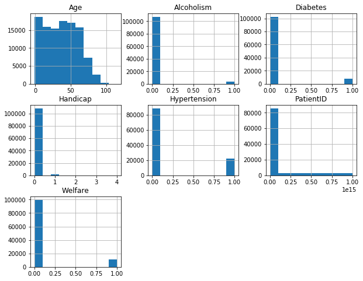

```python
df.hist(figsize=(10,8));
```

**The Summary Statistics indicate the following**:

The column that provides the most data to reach a well-informed conclusion is the age column. Seeing as most patients don't suffer from the illnesses on the dataset, I won't include them in the research questions for further analysis.

# Part 1 of Research - How does age and gender affect patients showing up to their scheduled appointments?

**Step 11**: The No_show column, which is the dependant variable, didn't appear on the summary statistics because the data-type is an object, so I used value_counts to into the amount of patients that did show up and those that did not to get a well rounded view of the data

# Sidenote - In the No_show column, 'No' represents patients that did show up, 'Yes' represents patients that didn't show up

```python
df.No_show.value_counts()
```

```
No     88208
Yes    22319
Name: No_show, dtype: int64
```

**Step 12**: After seeing the numericals of the amount of patients that show up and those that don't, I created variables seperating patients who did show up and those who didn't. These two variables will be used to plot the independant variables againt the dependant variable on the graphs for better visuals and clearer understanding of the differences on the graphs.

I begin with my fist independant variable, 'Age', by plotting the mean age of those who show up and those who don't to get an understanding of the average ages of patients to add perspective when drawing up the conclusion

```python
showed_up = df.No_show == 'No'
no_shows = df.No_show == 'Yes'
df.Age[showed_up].mean()
```

```
37.790064393252315
```

**Step 13**: The average age of patients that don't show up. Reasons explained above

```python
df.Age[no_shows].mean()
```

```
34.31766656212196
```

**Step 14**: I then created a function to group the Ages and added an extra column(AgeGroup) with the grouped lables.

> From ages:
> - 0 - 20 = Child
> - 20 - 40 = Young Adult
> - 40 - 60 = Adult
> - 60 - 80 = Mature Adult
> - 80+ = Advanced Years

The purpose of this was to assist in showing the numericals of each age group of patients who show up and those who don't which will further be represented in a histogram in which the bins were set to 20

```python
def Agerange(Age):
    if Age <= 20:
       return 'Child'
    elif Age <= 40:
       return 'Young Adult'
    elif Age <= 60:
     return 'Adult'
    elif Age <= 80:
     return 'Mature Adult'
    else :
        return 'Advanced Years'

df['AgeGroup']=df['Age'].apply(Agerange)
```

**Step 15**: I then use groupby to group the AgeGroup and the No_Show data and value_counts to represent the numericals of patients who showed up and didn't show up for each age Group. This is a statistical visual that shows us the numbers to be able to answer the research question

# Sidenote - In the No_show column, 'No' represents patients that did show up, 'Yes' represents patients that didn't show up

```python
df.groupby('AgeGroup')['No_show'].value_counts()
```

```
AgeGroup        No_show
Adult           No         24490
                Yes         5591
Advanced Years  No          2383
                Yes          469
Child           No         24753
                Yes         7096
Mature Adult    No         14373
                Yes         2537
Young Adult     No         22209
                Yes         6626
Name: No_show, dtype: int64
```

**Step 16** : The numericals above have be plotted on a histogram, using the age column and the showed_up and no_show variables to get a visual of the patient's show up rate by age. This visual gives a clear image of the selected data to be able to contribute to the conclusion

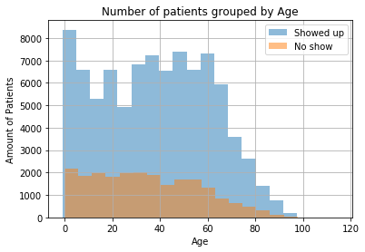

```python
df.Age[showed_up].hist(alpha=0.5,bins=20,label='Showed up')
df.Age[no_shows].hist(alpha=0.5,bins=20,label= 'No show')
plt.xlabel("Age")
plt.ylabel("Amount of Patients")
plt.legend(["Show up", "No Show"])

plt.title("Number of patients grouped by Age")
plt.legend();
```

**Step 17**: Before creating a graph to check the effects of gender, I first did a value_count to see how many men and women there are. There seems to be a significant difference between the two, this is a factor that will be kept in mind when coming to a conclusion

```python
df.Gender.value_counts()
```

```
F    71840
M    38687
Name: Gender, dtype: int64
```

**Step 18**: This is a numerical visual that indicates the amount of men and women who showed up to the scheduled appointments and those who did not show up. The data was groupped by Gender and No_show columns, then the values were counted using value_counts. This is a statistical visual that shows us the numbers to be able to answer the research question

# Sidenote - In the No_show column, 'No' represents patients that did show up, 'Yes' represents patients that didn't show up

```python
df.groupby('Gender')['No_show'].value_counts()
```

```
Gender  No_show
F       No         57246
        Yes        14594
M       No         30962
        Yes         7725
Name: No_show, dtype: int64
```

**Step 19**: The numericals above have be plotted on a bar graph, using the gender column and the showed_up and no_show variables to get a visual of the patient's show up rate by gender. This visual gives a clear image of the selected data to be able to contribute to the conclusion

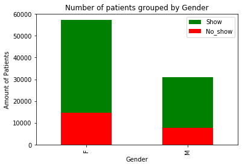

```python
df.Gender[showed_up].value_counts().plot(kind='bar', alpha=1, color='green',label='Show')
df.Gender[no_shows].value_counts().plot(kind='bar', alpha=1, color='red',label='No_show')
plt.xlabel("Gender")
plt.ylabel("Amount of Patients")
plt.legend(["Show up", "No Show"])

plt.title("Number of patients grouped by Gender")
plt.legend();
```

### Part 2 of Research - How does welfare and neighbourhoods impact patients showing up to their scheduled appointments?

**Step 20**: This is a numerical visual that indicates the amount of people who showed up to the scheduled appointments and those who did not show up while having welfare or not having welfare. The data was groupped by welfare, in which 0 represents no welfare and 1 represents those who have welfare. No_show was also grouped and value_counts was used to count the patients. This is a statistical visual that shows us the numbers to be able to answer the research question

# Sidenote - In the No_show column, 'No' represents patients that did show up, 'Yes' represents patients that didn't show up

```python
df.groupby('Welfare')['No_show'].value_counts()
```

```
Welfare  No_show
0        No         79925
         Yes        19741
1        No          8283
         Yes         2578
Name: No_show, dtype: int64
```

**Step 21**: The numericals above have be plotted on a bar graph, using the welfare column and the showed_up and no_show variables to get a visual of the patient's show up rate by welfare.This visual gives a clear image of the selected data to be able to contribute to the conclusion

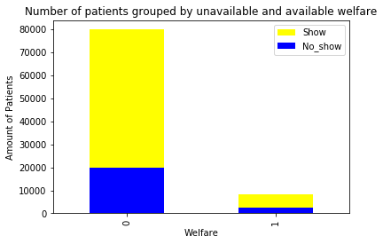

```python
df.Welfare[showed_up].value_counts().plot(kind='bar', alpha=1, color='Yellow',label='Show')
df.Welfare[no_shows].value_counts().plot(kind='bar', alpha=1, color='Blue',label='No_show')
plt.xlabel("Welfare")
plt.ylabel("Amount of Patients")
plt.legend(["Show up", "No Show"])

plt.title("Number of patients grouped by unavailable and available welfare")
plt.legend();
```

**Step 22**: This is a numerical visual that indicates the amount of people who showed up to the scheduled appointments and those who did not show up groupped by the health-care location's neighbourhood and used value_count to count the number of patients. This is a statistical visual that shows us the numbers to be able to answer the research question

# Sidenote - In the No_show column, 'No' represents patients that did show up, 'Yes' represents patients that didn't show up

```python
df.groupby('Neighbourhood')['No_show'].value_counts()
```

```
Neighbourhood      No_show
AEROPORTO          No            7
                   Yes           1
ANDORINHAS         No         1741
                   Yes         521
ANT??NIO HON??RIO  No          221
                              ...
TABUAZEIRO         Yes         573
UNIVERSIT??RIO     No          120
                   Yes          32
VILA RUBIM         No          710
                   Yes         141
Name: No_show, Length: 160, dtype: int64
```

**Step 22**: The numericals above have be plotted on a bar graph, using the Neighbourhood column and the No_show column to get a visual of the patient's show up rate by neighbourhood. This visual gives a clear image of the selected data to be able to contribute to the conclusion

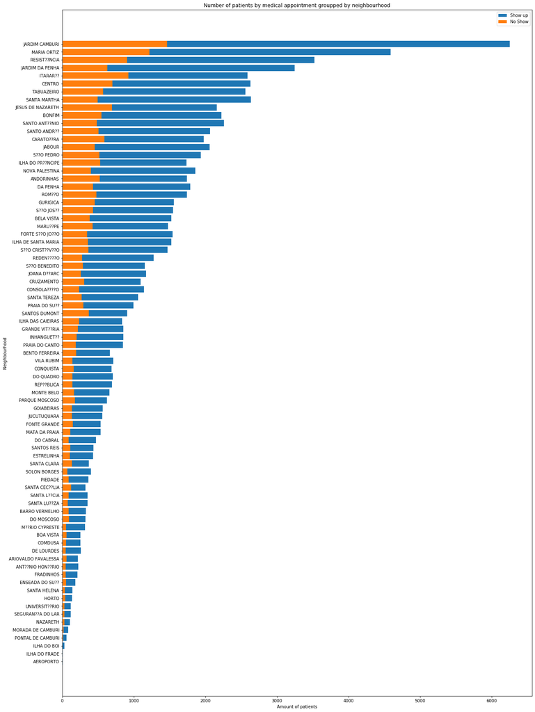

```python
df_groupped_by_neighborhood = df.groupby(['Neighbourhood', 'No_show']).count().unstack().PatientID
df_groupped_by_neighborhood["sum"] = df_groupped_by_neighborhood['No'] + df_groupped_by_neighborhood['Yes']
df_groupped_by_neighborhood.sort_values(by="sum", inplace=True)
df_groupped_by_neighborhood.dropna(inplace=True)


plt.figure(figsize=(20, 30))


plt.barh(df_groupped_by_neighborhood.index, df_groupped_by_neighborhood['No'].values)
plt.barh(df_groupped_by_neighborhood.index, df_groupped_by_neighborhood['Yes'].values)

plt.xlabel("Amount of patients")
plt.ylabel("Neighbourhood")
plt.legend(["Show up", "No Show"])

plt.title("Number of patients by medical appointment groupped by neighbourhood")

plt.show();
```

## Conclusions

> **Research Limitations** :
- There was lack of clarity on the dataset description, some information was availbale through Kaggle forum posts
- No official confrimation of where the data comes from
- Lack of information on how many health units share from the same database, this may lead to data inconsistancy
- The lack of data on the neighbourhood variable which doesn't indicate the location of the patient makes it restricting to make an in depth analysis of how impactful the location of the health centre is on the patient

- **Age**

The higher rates may occur because: Parents or guardians may have difficulties bringing the child to the appointment And the lower rates may occur because: Older people tend to have more pressing health related issues that must be attended to

- **Gender**

There is a significant difference between men and women in the data. One can assume that women generally tend to take better care of their health than men do.

There is a large amount of female patients, in the context of this data, the women and men have a similar no-showing proportion.

- **Neighborhood**

The data indicates that that Jardim Camburi is the one with most of the appointments in the state and actually is the most populous neighbourhood from "Espírito Santo".

Since we don't have enough data we can't investigate further for the reasons on why.